# ggplot Workshop

## Attribution

Shoutout to Rike who provided the materials that we are going to work through in this session!!

## Useful links/resources

There is lots of useful info online on making plots with ggplot2, but this book is a great starting point:

Wickham, H. and Grolemund, G. (2016) R for data science.

Another useful book is this one: [http://www.cookbook-r.com/Graphs/] (R cookbook)

On the grid package: http://ww2.amstat.org/publications/jse/v18n3/zhou.pdf

[This webpage] (https://rawgit.com/Z3tt/R-Tutorials/master/ggplot2/ggplot2-tutorial.html) is also great as a cheat sheet

## Loading ggplot2 into R

To start using ggplot2, first open RStudio, then install and load the package with the following code:

```r
install.packages("ggplot2")
library(ggplot2)
```

There is a lot of information about ggplot2 online, so if you get stuck you can try to google what you are trying to do. There is also a useful data visualisation cheat sheet - once you have used ggplot2 a bit, it will become more and more useful: https://www.rstudio.com/resources/cheatsheets/

## Some basics of ggplot2

In your code, you need to specify a few things:

- the type of plot you want (called geom)
- how you display your data - for example the colour or size of dots, bars etc (with scale functions)
- how the overall plot looks (the theme)
- whether you want subplots of your data (called facets)

As with anything in R there are several different ways that you can go about doing this…

Hadley (the dude that wrote ggplot) reccomends starting like this

```r
ggplot(data = <DATA>) +
  <GEOM_FUNCTION>(mapping = aes(<MAPPINGS>))
```

But you can also code it like this

```r
ggplot(data = <DATA>, mapping = aes(<MAPPINGS>))+
  <GEOM_FUNCTION>()
```

either way you do it the MAPPINGS are the important bit for determining what is actually going in to your plot

To get something to appear on your plot you need to MAP it to an AES(thetic), this might be the size or the colour, or the shape given to a data point

## A very basic plot in ggplot2

We will use data that are in-built in R, using the iris, diamonds and mtcars datasets.

```r
str(iris)
```

```
## 'data.frame':    150 obs. of  5 variables:
##  $ Sepal.Length: num  5.1 4.9 4.7 4.6 5 5.4 4.6 5 4.4 4.9 ...
##  $ Sepal.Width : num  3.5 3 3.2 3.1 3.6 3.9 3.4 3.4 2.9 3.1 ...
##  $ Petal.Length: num  1.4 1.4 1.3 1.5 1.4 1.7 1.4 1.5 1.4 1.5 ...
##  $ Petal.Width : num  0.2 0.2 0.2 0.2 0.2 0.4 0.3 0.2 0.2 0.1 ...
##  $ Species     : Factor w/ 3 levels "setosa","versicolor",..: 1 1 1 1 1 1 1 1 1 1 ...
```

```r
# Have a look at the iris dataset, so you know which variables there are and what types of variables they are
```

We will start with some short code that will produce a plot in ggplot2. The basic pattern of the ggplot2 function first names the dataset, then the x and y variables. With `geom_`, you add the type of plot you want:

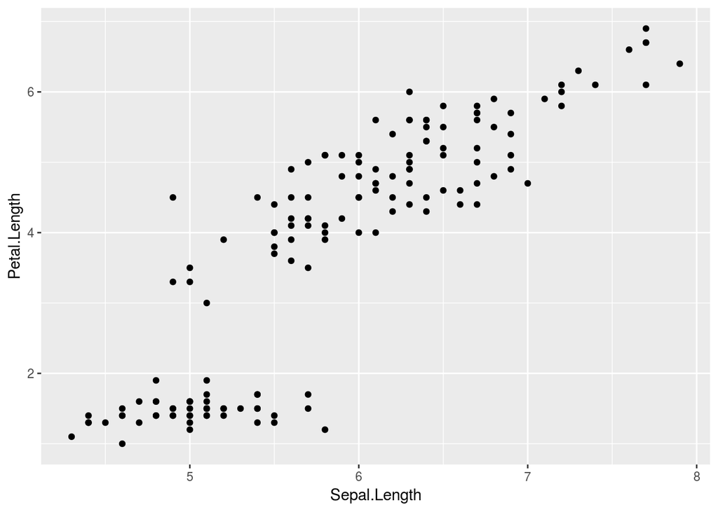

```r
ggplot(data=iris, aes(x=Sepal.Length, y=Petal.Length)) + geom_point()
```

```r
# this will now produce a basic scatterplot of sepal lengths against petal lengths
```

The plot will be empty if you don’t specify the type of plot you want:

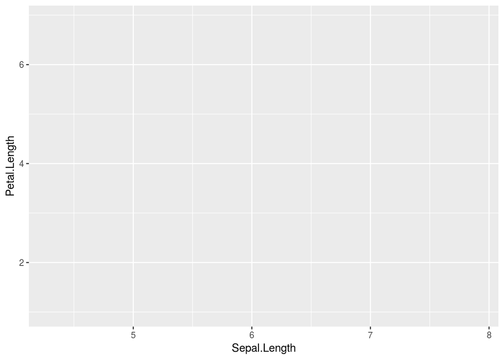

```r
ggplot(data=iris, aes(x=Sepal.Length, Petal.Length))
```

## Customising a plot

### Axis labels

We can now start to customise the plot, so it looks exactly how we want it to look. We can change the axis labels by adding `xlab` or `ylab`:

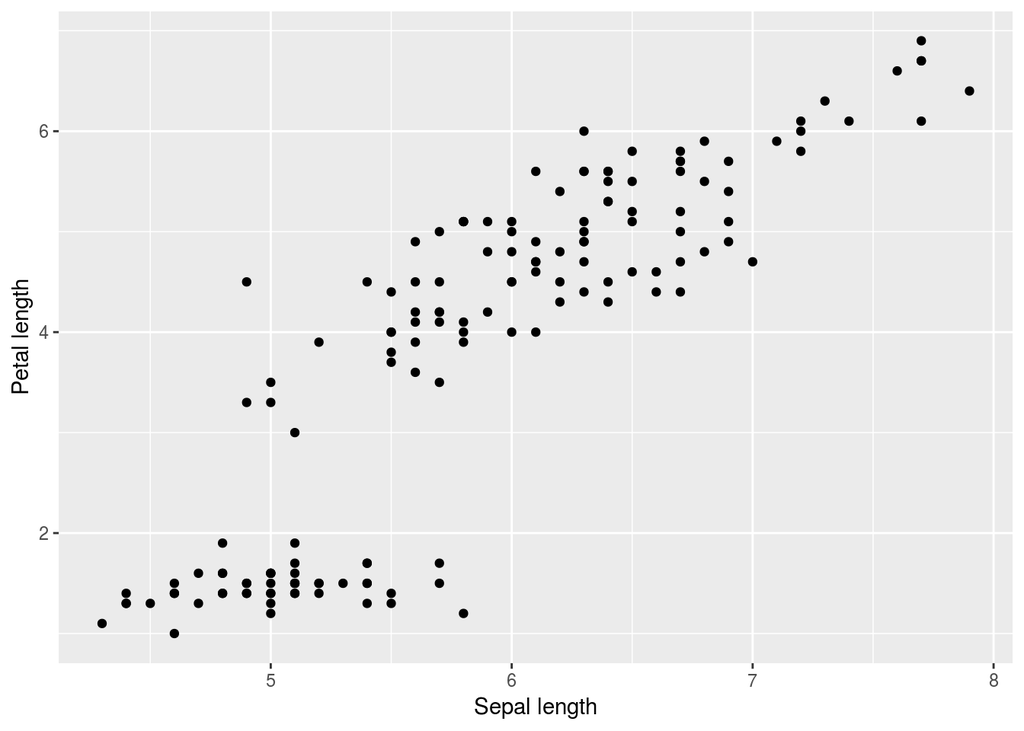

```r
ggplot(data=iris, aes(x=Sepal.Length, y=Petal.Length)) +  geom_point() + xlab("Sepal length") + ylab("Petal length")
```

### Size and transparency

If you have a lot of data points, it can be difficult to see all of the points as they might overlap. You can change the size or transparency of the points so they are easier to see by adding the `size` or `alpha` arguments in to your MAPPING

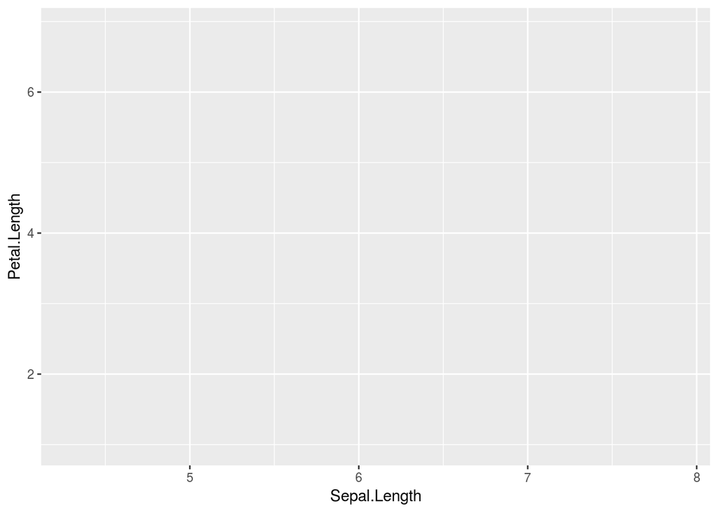

```r
#basic plot
ggplot(data=iris, mapping = aes(x=Sepal.Length, y=Petal.Length))
```

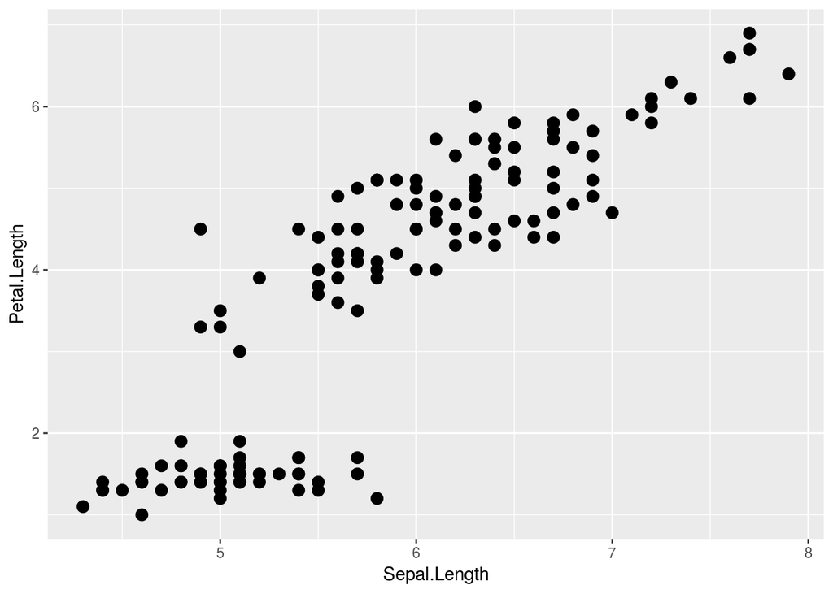

```r
# changing the size to make the dots bigger


ggplot(data=iris, mapping = aes(x=Sepal.Length, y=Petal.Length))+
  geom_point(size = 3)
```

Can you change the transparency of the points in a similar way

HINT: `alpha` takes values between 0-1

### Colour

In ggplot2, we can change things like the colour, size or shape of our data points, either by changing all of them, or by making them look different depending on another variable. We can change the colour of all dots by defining the colour within `geom_point()`:

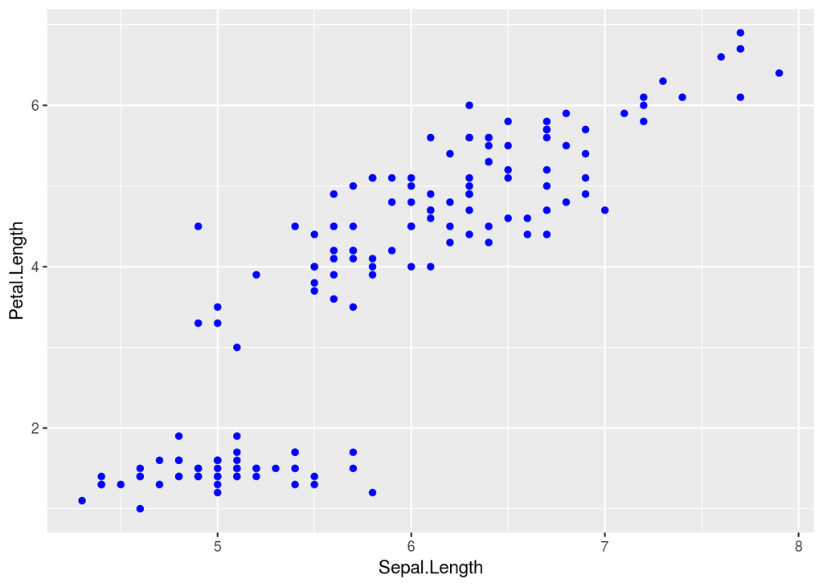

```r
ggplot(data=iris, aes(x=Sepal.Length, y=Petal.Length))+
  geom_point(color="blue")
```

We could also change the colour of each dot, depending on the type of species it is. To do so we need to add `aes` within `geom_point()`:

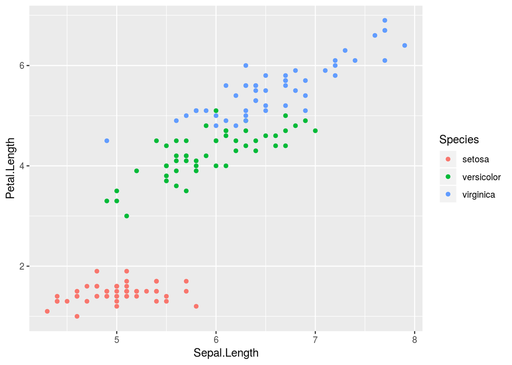

```r
ggplot(data=iris, aes(x=Sepal.Length, y=Petal.Length))+
  geom_point(aes(color=Species))
```

```r
# Note that there is a legend in your plot now!
```

Look we have a legend!!

This brings us to an important point about changing things inside vs outside the AES(thetic).

- Inside the AES() this information will appear in a legend
- Outside the AES() this information will be hidden from the legend

Have a play around here to get the legend to show the colours but not the size (whilst still plotting dots of size 3)

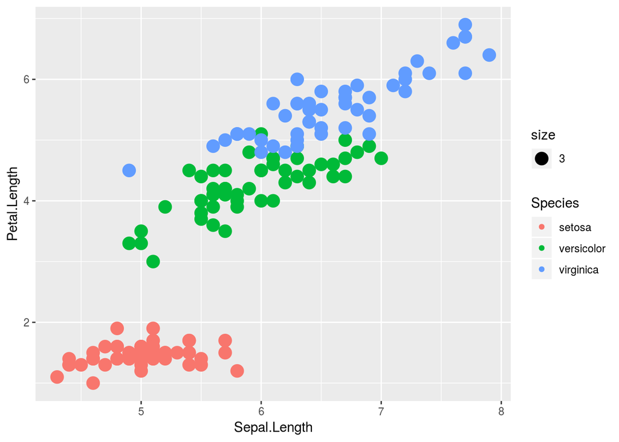

```r
ggplot(data=iris, aes(x=Sepal.Length, y=Petal.Length))+
  geom_point(aes(size = 3, color=Species))
```

The plot will be made with default colours, different for each species. To customise the colours, we need to adjust the scales:

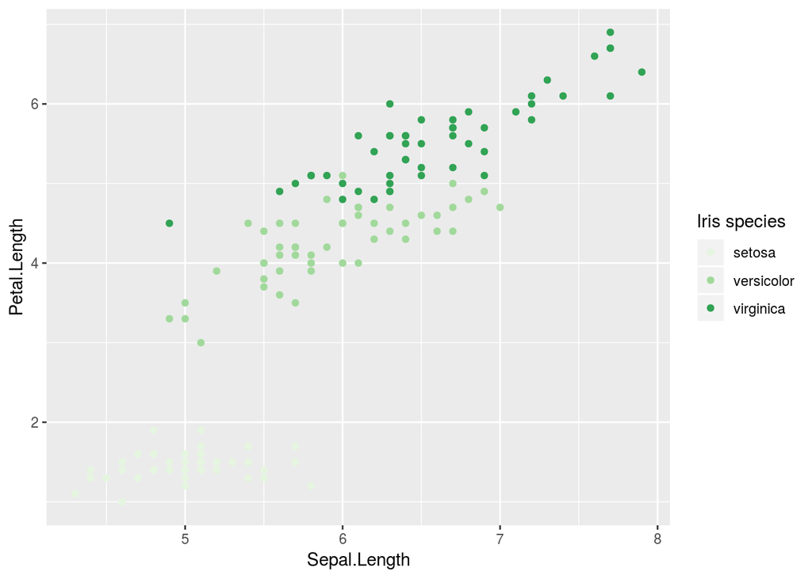

```r
ggplot(data=iris, aes(x=Sepal.Length, y=Petal.Length))+
  geom_point(aes(colour=Species))+
  scale_colour_brewer(palette="Greens", name="Iris species")
```

The scale function is used to customise how our data look, in this case we want to customise the colours in the plot. Whatever we specified in `geom_point` as an aesthetic, in this case colour, we need to put into the scale function: `scale_colour`. Here we will use colours from the RColorBrewer package, so we add `brewer` at the end. Inside the bracket we specify which colours we want to use, and `name` specifies the title of the legend. If you want to see all of the colour options in RColorBrewer, run the following code:

```r
library(RColorBrewer)
display.brewer.all()
```

In the previous example we used a categorical variable (Species) to set the colours. We can also use continuous variables for colours - the colours will change along a gradient:

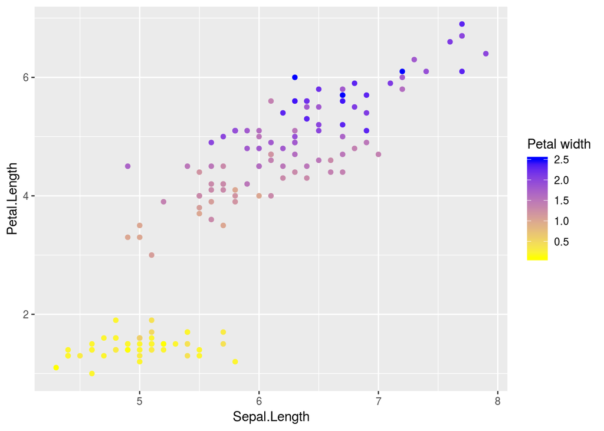

```r
ggplot(data=iris, aes(x=Sepal.Length, y=Petal.Length))+
  geom_point(aes(colour=Petal.Width))+
  scale_colour_gradient(low="yellow", high="blue", name="Petal width")
```

In this example, we did not use RColorBrewer, but in-built R colour names. You can find a (very long) list of colour names in R here: http://www.stat.columbia.edu/~tzheng/files/Rcolor.pdf

### Shapes

We can change the dots to different symbols too, for example open circles or triangles. Each symbol corresponds to a number, which we add in `geom_point()`:

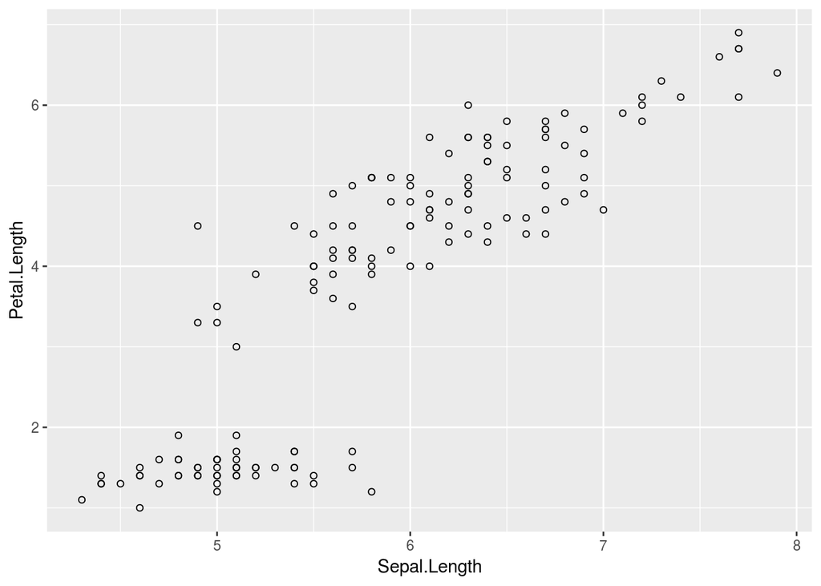

```r
ggplot(data=iris, aes(x=Sepal.Length, y=Petal.Length))+
  geom_point(shape=1)
```

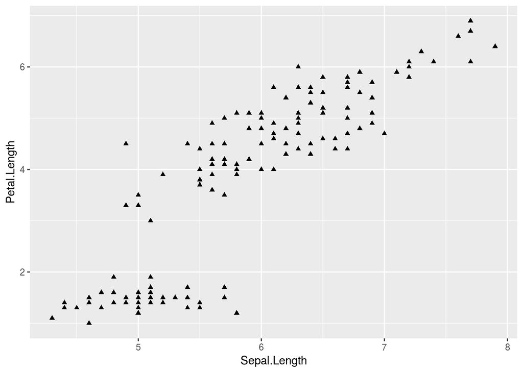

```r
ggplot(data=iris, aes(x=Sepal.Length, y=Petal.Length))+
  geom_point(shape=17)
```

We could also change the dots to symbols depending on another variable - similar to changing the colour depending on the species, as in the colour example. This can be useful if we need to use black-and-white plots:

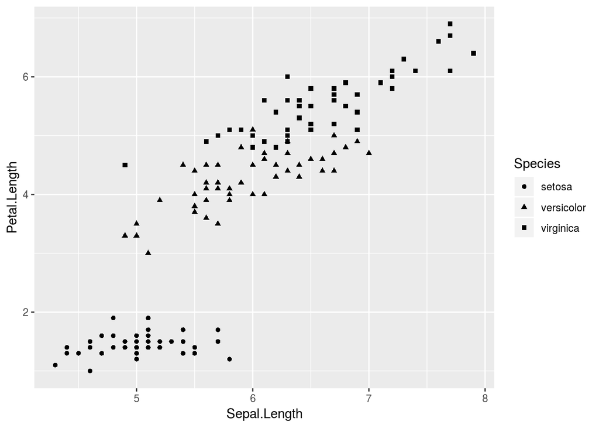

```r
ggplot(data=iris, aes(x=Sepal.Length, y=Petal.Length))+
  geom_point(aes(shape=Species))
```

### Zooming in on a plot

Sometimes we might not want to display the whole range of the x- and y-axes, or we want to start them from 0. We can specify the exact axes ranges we want to display using `coord_cartesian()`:

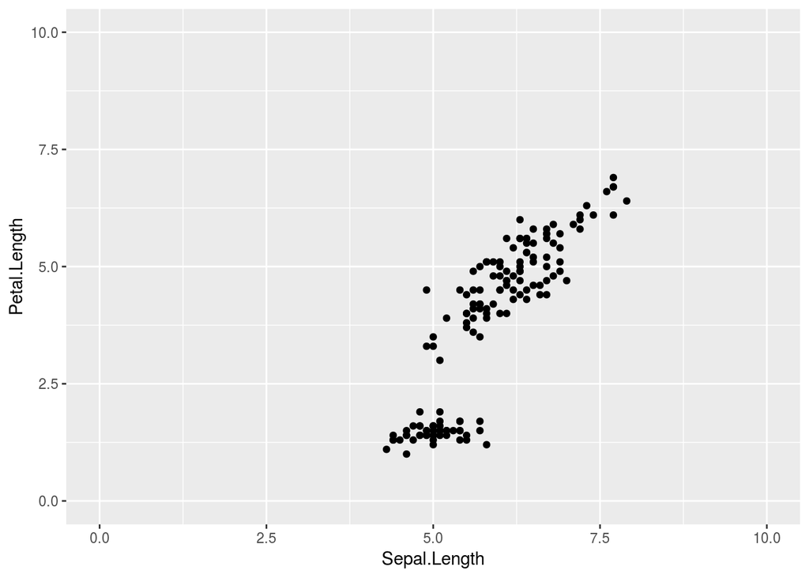

```r
ggplot(data=iris, aes(x=Sepal.Length, y=Petal.Length))+
  geom_point()+
  coord_cartesian(xlim=c(0,10), ylim=c(0,10))
```